# Two Sample Studies

Arnab Aich

## Types of Data and Analysis

In statistics, data can be classified into different types based on the number of variables involved and the nature of these variables. Understanding these distinctions is crucial for selecting appropriate statistical methods and interpreting results effectively. Here are some common types of data and the corresponding analyses:

### Bivariate Data

- **Definition**: Bivariate data consists of observations that have two variables measured for each individual or case. The main goal is to analyze the relationship between these two variables.
- **Examples**: Height and weight of individuals, study time and test scores.
- **Types of Analysis**: *Simple Linear Regression* (for continuous variables), and cross-tabulation or *chi-square tests* (for categorical variables).

### Paired Data

- **Definition**: Paired data arises when there is a natural pairing between two sets of data, where each value in one set is paired with a value in another set. Often, this occurs when the same subject is measured under different conditions.
- **Examples**: Blood pressure measurements before and after treatment, test scores of students before and after a training program.
- **Types of Analysis**: Paired t-tests, paired sample correlation, or repeated measures ANOVA for continuous variables.

### Multivariate Data

- **Definition**: Multivariate data involve more than two variables measured for each individual or case. The goal is to understand the relationships between multiple variables simultaneously.
- **Examples**: A survey with multiple questions, each representing a different variable like age, gender, income, etc.
- **Types of Analysis**: *Multiple Linear regression*, factor analysis, *2-way ANOVA* etc.

## Types of Variables

- **Dependent (Response) Variable**: This is the outcome variable that we are interested in predicting or explaining. It is also known as the response variable.
- **Covariates (X)**: These are the predictor variables that are believed to influence or explain changes in the dependent variable. Covariates can be continuous (e.g., age, temperature) or categorical (e.g., gender, treatment type).
- Example: In a study examining the effect of study time (X) on test scores (response variable), “study time” is the covariate, and “test score” is the dependent variable.

## Bivariate Data Analysis

Bivariate data involves examining the relationship between two variables. Depending on the nature of these variables (categorical or continuous), different types of analysis can be applied. Here, we will discuss three common combinations:

### Categorical vs. Categorical

For two categorical variables, contingency tables and chi-square tests are used to assess if there is an association between them.Graphical representation can be done using multiple bar plots.

Example: Gender vs. Preferred Mode of Transportation

- **Data**: We have data on individuals’ gender and their preferred mode of transportation (Car, Bicycle, Public Transport).
- **Objective**: To check if there is an association between gender and preferred mode of transportation.

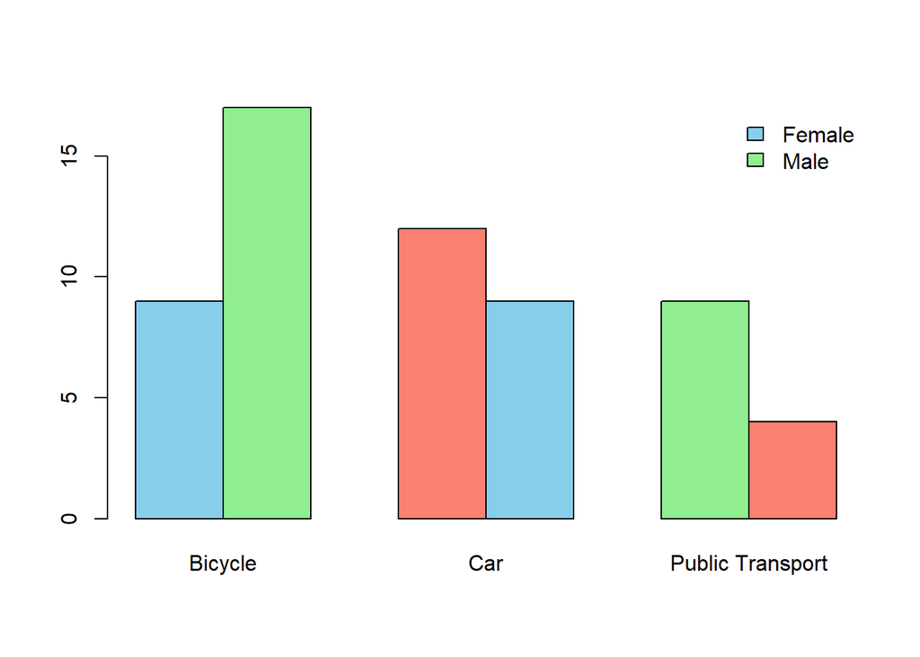

- **Analysis**: Use a chi-square test of independence to determine if there is a significant association between gender and transportation preference.

### Categorical vs. Continuous

When one variable is categorical and the other is continuous, we typically use boxplots to visualize differences and analysis of variance (ANOVA) to test for significant differences.

Example: Smoking Status vs. Blood Pressure

- **Data**: We have blood pressure readings of individuals categorized as smokers or non-smokers.
- **Objective**: To determine if there is a difference in average blood pressure between smokers and non-smokers.

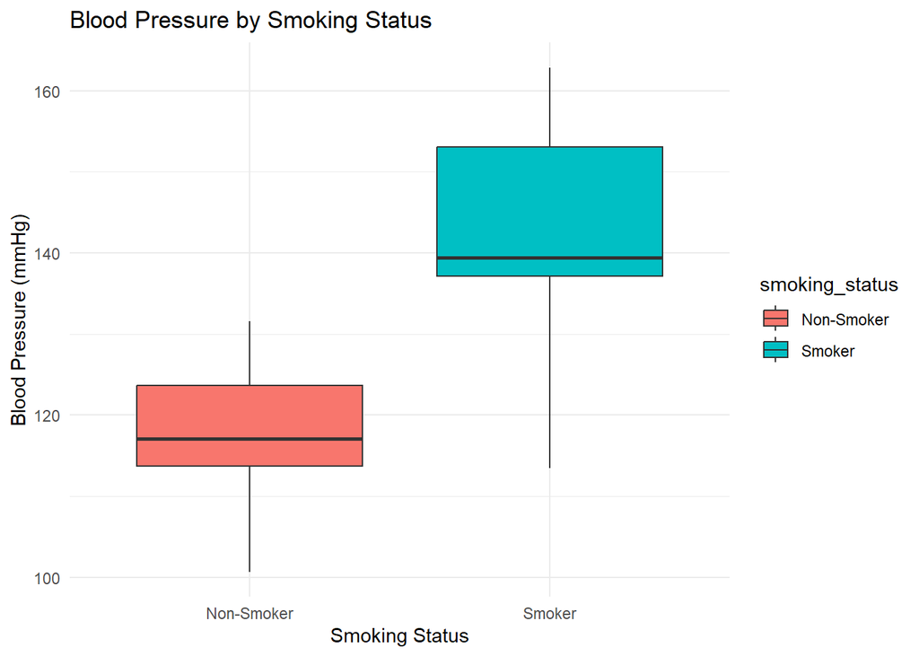

- **Analysis**: Use ANOVA to test if there is a significant difference in blood pressure between the groups.

### Continuous vs. Continuous

When both variables are continuous, we often use scatterplots to visualize the relationship and linear regression or correlation to analyze it. For example:

Example: Height vs. Weight

- **Data**: We have the heights and weights of 50 individuals.
- **Objective**: To analyze if there is a relationship between an individual’s height and weight.

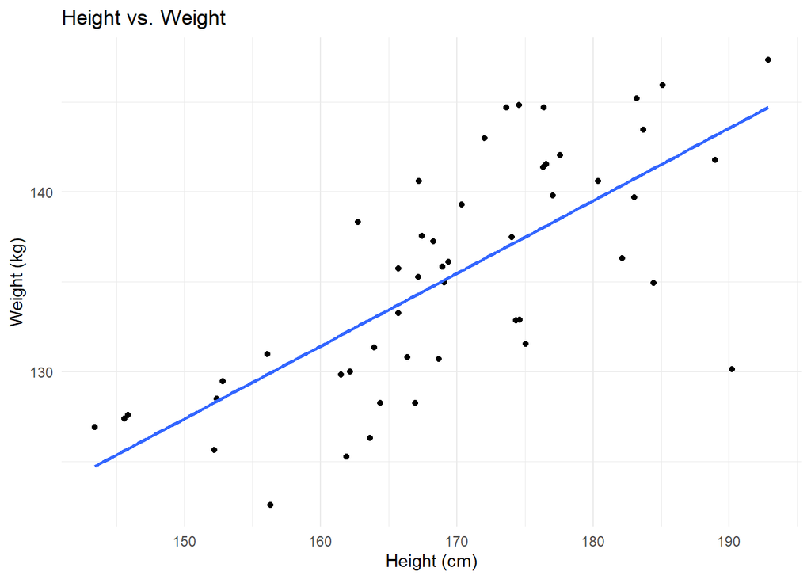

- **Analysis**: Use correlation to measure the strength of the relationship, and linear regression to model it.

## Summary Table

Here is a summary of the types of data, analysis methods, and examples discussed above:

| Type of Data | Definition & Analysis Methods | Example | Visualization |
| --- | --- | --- | --- |
| **Bivariate Data** | Two variables measured together; analyze relationships using regression (for continuous) or chi-square tests (for categorical). | Height and weight of individuals, study time and test scores. | Scatterplots, bar plots |
| **Paired Data** | Two sets of data with natural pairing; analyze using paired t-tests, correlations, or repeated measures ANOVA. | Blood pressure before and after treatment, test scores before and after training. | Side-by-side bar plots, line plots |
| **Multivariate Data** | Multiple variables measured; analyze using multiple regression, factor analysis, or 2-way ANOVA. | Survey data with variables like age, income, and gender. | Multidimensional scatterplots, heatmaps |
| **Categorical vs. Categorical** | Test association between two categorical variables using chi-square tests. | Gender vs. Preferred Mode of Transportation | Bar plots, stacked bar plots |
| **Categorical vs. Continuous** | Compare means across groups using ANOVA or visualize differences with boxplots. | Smoking Status vs. Blood Pressure | Boxplots, violin plots |
| **Continuous vs. Continuous** | Examine the relationship between two continuous variables using correlation or regression. | Height vs. Weight | Scatterplots with regression lines |
| **Dependent (Response) Variable** | Outcome variable that is predicted or explained. | Test scores in relation to study time | Dependent variables are typically plotted on the y-axis. |
| **Covariates (X)** | Predictor variables that explain changes in the dependent variable. | Study time affecting test scores | Plotted on the x-axis or as groups/categories. |